# Biostat 203B Homework 3

Due Feb 23 @ 11:59PM

Author

Chuanliang Chen, UID: 106152237

Load necessary libraries (you can add more as needed).

```r
suppressPackageStartupMessages({
  library(arrow)
  library(gtsummary)
  library(memuse)
  library(pryr)
  library(R.utils)
  library(tidyverse)
  library(ggplot2)
  library(tidyr)
  library(dplyr)
  library(scales)
  library(lubridate)
  library(jpeg)
  library(ggplot2)
  library(gridExtra)
  library(cowplot)
  library(lubridate)
})
```

Display your machine memory.

```r
memuse::Sys.meminfo()
```

```
Totalram:  15.233 GiB
Freeram:    9.924 GiB
```

In this exercise, we use tidyverse (ggplot2, dplyr, etc) to explore the [MIMIC-IV](https://mimic.mit.edu/docs/iv/) data introduced in [homework 1](https://ucla-biostat-203b.github.io/2024winter/hw/hw1/hw1.html) and to build a cohort of ICU stays.

## Q1. Visualizing patient trajectory

Visualizing a patient’s encounters in a health care system is a common task in clinical data analysis. In this question, we will visualize a patient’s ADT (admission-discharge-transfer) history and ICU vitals in the MIMIC-IV data.

### Q1.1 ADT history

Do a similar visualization for the patient with `subject_id` 10013310 using ggplot.

Hint: We need to pull information from data files `patients.csv.gz`, `admissions.csv.gz`, `transfers.csv.gz`, `labevents.csv.gz`, `procedures_icd.csv.gz`, `diagnoses_icd.csv.gz`, `d_icd_procedures.csv.gz`, and `d_icd_diagnoses.csv.gz`. For the big file `labevents.csv.gz`, use the Parquet format you generated in Homework 2. For reproducibility, make the Parquet folder `labevents_pq` available at the current working directory `hw3`, for example, by a symbolic link. Make your code reproducible.

*Answer*

```r
if (!file.exists("labevents_pq")) {
  system("ln -s ~/mimic/hosp/labevents_parquet labevents_pq")
}

#This step is to read the data from the csv files
read_csv <- readr::read_csv
patients <- read_csv("~/mimic/hosp/patients.csv.gz",
                     show_col_types = FALSE)
admissions <- read_csv("~/mimic/hosp/admissions.csv.gz",
                       show_col_types = FALSE)
transfers <- read_csv("~/mimic/hosp/transfers.csv.gz",
                      show_col_types = FALSE)
procedures_icd <- read_csv("~/mimic/hosp/procedures_icd.csv.gz",
                           show_col_types = FALSE)
diagnoses_icd <- read_csv("~/mimic/hosp/diagnoses_icd.csv.gz",
                          show_col_types = FALSE)
d_icd_procedures <- read_csv("~/mimic/hosp/d_icd_procedures.csv.gz",
                             show_col_types = FALSE)
d_icd_diagnoses <- read_csv("~/mimic/hosp/d_icd_diagnoses.csv.gz",
                            show_col_types = FALSE)

labevents <- arrow::open_dataset("labevents_pq", format = "parquet")


# This step is to filter the data for the patient with subject_id 10013310
filter_subject <- function(df) {
  df %>% dplyr::filter(subject_id == 10013310)
}

patient_labevents <- labevents %>%
  filter_subject() %>%
  collect()

patient_admissions <- admissions %>% filter_subject()
patient_transfers <- transfers %>% filter_subject()
patient_procedures_icd <- procedures_icd %>% filter_subject()
patient_diagnoses_icd <- diagnoses_icd %>% filter_subject()

patient_info <- patients %>%
  filter_subject() %>%
  left_join(admissions %>% select(subject_id, race),
            by = "subject_id") %>%
  dplyr::mutate(
    title = paste("Patient", subject_id, ",", gender, ",",
                  anchor_age, "years old,", race)
  ) %>%
  dplyr::pull(title)

#This is to get the top 3 diagnoses and title
top_diagnoses <- patient_diagnoses_icd %>%
  filter(subject_id == 10013310) %>%
  filter(seq_num %in% 1:3) %>%
  group_by(seq_num) %>%
  filter(dplyr::row_number() == 1) %>%
  ungroup() %>%
  inner_join(d_icd_diagnoses, by = "icd_code") %>%
  pull(long_title)

top_diagnoses_subtitle <- paste("Top Diagnoses:\n",
                                paste(top_diagnoses, collapse = "\n"))

adt_data <- patient_transfers %>%
  filter(eventtype %in% c("admit", "discharge", "transfer", "ED")) %>%
  select(subject_id, eventtype, intime, outtime, careunit)

adt_data_plot_clean <- adt_data %>%
  filter(!is.na(intime) & !is.na(outtime) & !is.na(careunit)) %>%
  mutate(
    line_size = ifelse(grepl("ICU|CCU", careunit), 8, 4),
    y_position = "ADT"
  )

lab_data <- patient_labevents %>%
  select(subject_id, charttime) %>%
  mutate(y_position = "Lab", line_size = 2)

procedure_data <- patient_procedures_icd %>%
  inner_join(d_icd_procedures, by = "icd_code") %>%
  select(long_title, chartdate) %>%
  mutate(
    y_position = "Procedure",
    line_size = 2,
    chartdate = as.POSIXct(chartdate, format = "%Y-%m-%d")
  )

# This is to create the plot
your_plot <- ggplot() +
  geom_segment(data = adt_data_plot_clean,
               aes(x = intime, xend = outtime, y = y_position,
                   yend = y_position, color = careunit,
                   size = as.factor(line_size))) +
  geom_point(data = lab_data,
             aes(x = charttime, y = y_position),
             color = "black", size = 2, shape = 3) +
  geom_point(data = procedure_data,
             aes(x = chartdate, y = y_position, shape = long_title),
             color = "black", size = 8) +
  scale_shape_manual(values = c(0:9)) +
  theme_minimal() +
  scale_y_discrete(limits = c("Procedure", "Lab", "ADT")) +
  theme(legend.position = "bottom",
        axis.title.y = element_blank(),
        axis.ticks.y = element_blank(),
        axis.text.y = element_text(angle = 0, hjust = 1)) +
  scale_size_manual(values = c("4" = 4, "8" = 8), guide = "none") +
  guides(color = guide_legend(nrow = 6, byrow = TRUE),
         shape = guide_legend(nrow = 6, byrow = TRUE,
                              title = "Procedure")) +
  labs(x = "Calendar Time", title = patient_info,
       subtitle = top_diagnoses_subtitle)
ggsave("patient_timeline_plot.jpeg", plot = your_plot,
       width = 20, height = 8, dpi = 400)
```

Check the plot saved in the current working directory.

### Q1.2 ICU stays

Do a similar visualization for the patient `10013310`.

**Answer**

```r
# This step is to create the symbolic link
dataset <- arrow::open_dataset("~/mimic/icu/chartevents.csv", format = "csv")
parquet_path <- "~/mimic/icu/chartevents_parquet"

if (!dir.exists(parquet_path)) {
  arrow::write_dataset(dataset, parquet_path, format = "parquet")
  message("Parquet dataset created at: ", parquet_path)
} else {
  message("Parquet dataset already exists at: ", parquet_path)
}
```

```r
# This step is to read the data from the csv files
if (!file.exists("chartevents_pq")) {
  system("ln -s ~/mimic/icu/chartevents_parquet chartevents_pq")
}
read_csv <- readr::read_csv
chartevents_vitals_filtered <-
  read_csv("~/mimic/icu/chartevents_vitals_filtered.csv.gz",
                                        show_col_types = FALSE)
d_items <- read_csv("~/mimic/icu/d_items.csv.gz",
                    show_col_types = FALSE)

chartevents <- arrow::open_dataset("chartevents_pq", format = "parquet")

# This step is to filter the data for the patient with subject_id 10013310
filter_subject <- function(df) {
  df %>% dplyr::filter(subject_id == 10013310)
}
patient_chartevents <- chartevents %>%
  filter_subject() %>%
  collect()
patient_chartevents_vitals_filtered <-
  chartevents_vitals_filtered %>% filter_subject()

chartevents_vitals_filtered <- chartevents_vitals_filtered %>%
  mutate(value = as.numeric(value))

patient_chartevents <- patient_chartevents %>%
  mutate(value = as.numeric(value))

combined_data <- chartevents_vitals_filtered %>%
  inner_join(patient_chartevents, by = c("itemid", "charttime", "value")) %>%
  select(subject_id = subject_id.x, itemid, charttime, value, stay_id, valuenum)

combined_data_with_abbreviation <- combined_data %>%
  left_join(d_items %>% select(itemid, abbreviation), by = "itemid")

# This step is to choose the selected itemids
selected_itemids <- c(220045, 220181, 220179, 220210, 223761)

filtered_data <- combined_data_with_abbreviation %>%
  filter(itemid %in% selected_itemids)

filtered_data$charttime <- as.POSIXct(filtered_data$charttime)
filtered_data$charttime_formatted <- format(filtered_data$charttime,
                                            "%b %d %H:%M")
# This step is to create the plot
vital_plot <- ggplot(filtered_data, aes(x = charttime, y = value,
                                        color = abbreviation)) +
  geom_line() +
  geom_point() +
  facet_grid(abbreviation ~ stay_id, scales = "free", space = "fixed") +
  scale_x_datetime(date_breaks = "12 hours", date_labels = "%b %d %H:%M") +
  theme_minimal() +
  labs(
    title = "Patient 10013310 ICU stays - Vitals",
    x = "Time (Month Day Hour:Minute)",
    y = "Value",
    color = "Measurement"
  ) +
  theme(
    axis.text.x = element_text(angle = 45, hjust = 1, size = 8),
    strip.text.x = element_text(size = 8, color = "white"),
    strip.text.y = element_text(size = 8, color = "white"),
    axis.title.y = element_blank(),
    axis.title.x = element_blank(),
    legend.position = "none",
    strip.background = element_rect(fill = "grey", color = "grey"),
    panel.border = element_rect(fill = NA, color = "grey", size = 0.5),
    plot.title = element_text(hjust = 0, size = 14)
  )

ggsave("Patient_Vitals.jpeg", plot = vital_plot, width = 20, height = 8,
       dpi = 300)
```

Check the plot saved in the current working directory.

## Q2. ICU stays

`icustays.csv.gz` (https://mimic.mit.edu/docs/iv/modules/icu/icustays/) contains data about Intensive Care Units (ICU) stays. The first 10 lines are

```bash
zcat < ~/mimic/icu/icustays.csv.gz | head
```

```
subject_id,hadm_id,stay_id,first_careunit,last_careunit,intime,outtime,los
10000032,29079034,39553978,Medical Intensive Care Unit (MICU),Medical Intensive Care Unit (MICU),2180-07-23 14:00:00,2180-07-23 23:50:47,0.4102662037037037
10000980,26913865,39765666,Medical Intensive Care Unit (MICU),Medical Intensive Care Unit (MICU),2189-06-27 08:42:00,2189-06-27 20:38:27,0.4975347222222222
10001217,24597018,37067082,Surgical Intensive Care Unit (SICU),Surgical Intensive Care Unit (SICU),2157-11-20 19:18:02,2157-11-21 22:08:00,1.1180324074074075
10001217,27703517,34592300,Surgical Intensive Care Unit (SICU),Surgical Intensive Care Unit (SICU),2157-12-19 15:42:24,2157-12-20 14:27:41,0.9481134259259258
10001725,25563031,31205490,Medical/Surgical Intensive Care Unit (MICU/SICU),Medical/Surgical Intensive Care Unit (MICU/SICU),2110-04-11 15:52:22,2110-04-12 23:59:56,1.338587962962963
10001884,26184834,37510196,Medical Intensive Care Unit (MICU),Medical Intensive Care Unit (MICU),2131-01-11 04:20:05,2131-01-20 08:27:30,9.171817129629629
10002013,23581541,39060235,Cardiac Vascular Intensive Care Unit (CVICU),Cardiac Vascular Intensive Care Unit (CVICU),2160-05-18 10:00:53,2160-05-19 17:33:33,1.3143518518518518
10002155,20345487,32358465,Medical Intensive Care Unit (MICU),Medical Intensive Care Unit (MICU),2131-03-09 21:33:00,2131-03-10 18:09:21,0.8585763888888889
10002155,23822395,33685454,Coronary Care Unit (CCU),Coronary Care Unit (CCU),2129-08-04 12:45:00,2129-08-10 17:02:38,6.178912037037037
```

### Q2.1 Ingestion

Import `icustays.csv.gz` as a tibble `icustays_tble`.

*Answer*

```r
icustays_tble <- read_csv("~/mimic/icu/icustays.csv.gz",
                          show_col_types = FALSE)
```

### Q2.2 Summary and visualization

How many unique `subject_id`? Can a `subject_id` have multiple ICU stays? Summarize the number of ICU stays per `subject_id` by graphs.

*Answer*

```r
unique_subjects <- icustays_tble %>%
  summarise(unique_subjects = n_distinct(subject_id))

icu_stays_per_subject <- icustays_tble %>%
  group_by(subject_id) %>%
  summarise(icu_stays = n()) %>%
  ungroup()

multiple_icu_stays <- icu_stays_per_subject %>%
  filter(icu_stays > 1)

if(nrow(multiple_icu_stays) > 0) {
  cat("Yes, a subject_id can have multiple ICU stays.\n")
} else {
  cat("No, each subject_id corresponds to a single ICU stay.\n")
}
```

```
Yes, a subject_id can have multiple ICU stays.
```

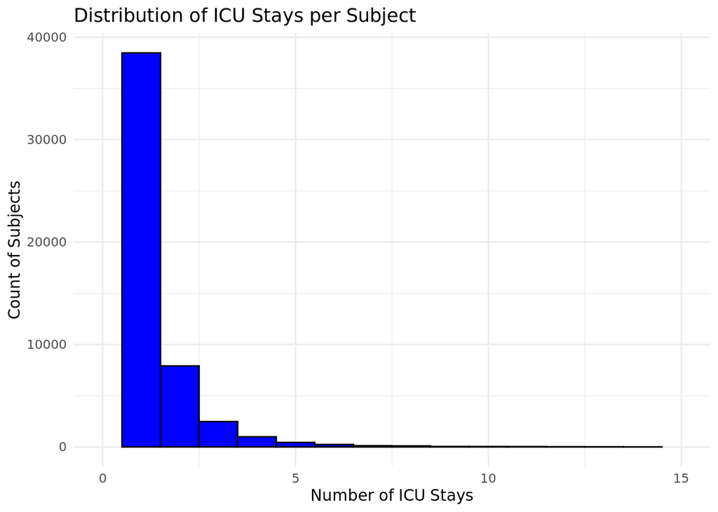

```r
ggplot(icu_stays_per_subject, aes(x = icu_stays)) +
  geom_histogram(binwidth = 1, fill = "blue", color = "black") +
  xlim(0, 15) +  # Setting hard limits on the x-axis
  theme_minimal() +
  labs(title = "Distribution of ICU Stays per Subject",
       x = "Number of ICU Stays",
       y = "Count of Subjects")
```

From the histogram, we can see that most subjects have less than 3 ICU stay, and the number of ICU stays per subject decreases as the number of ICU stays increases. And there are rows removed for N/A data.

### Q3. `admissions` data

#Information of the patients admitted into hospital is available in `admissions.csv.gz`. See https://mimic.mit.edu/docs/iv/modules/hosp/admissions/ for details of each field in this file. The first 10 lines are

```bash
zcat < ~/mimic/hosp/admissions.csv.gz | head
```

[output not shown]

### Q3.1 Ingestion

Import `admissions.csv.gz` as a tibble `admissions_tble`.

*Answer*

```r
admissions_tble <- read_csv("~/mimic/hosp/admissions.csv.gz",
                            show_col_types = FALSE)
```

### Q3.2 Summary and visualization

Summarize the following information by graphics and explain any patterns you see.

- number of admissions per patient
- admission hour (anything unusual?)
- admission minute (anything unusual?)
- length of hospital stay (from admission to discharge) (anything unusual?)

According to the [MIMIC-IV documentation](https://mimic.mit.edu/docs/iv/about/concepts/#date-shifting),

> All dates in the database have been shifted to protect patient confidentiality. Dates will be internally consistent for the same patient, but randomly distributed in the future. Dates of birth which occur in the present time are not true dates of birth. Furthermore, dates of birth which occur before the year 1900 occur if the patient is older than 89. In these cases, the patient’s age at their first admission has been fixed to 300.

*Answer*

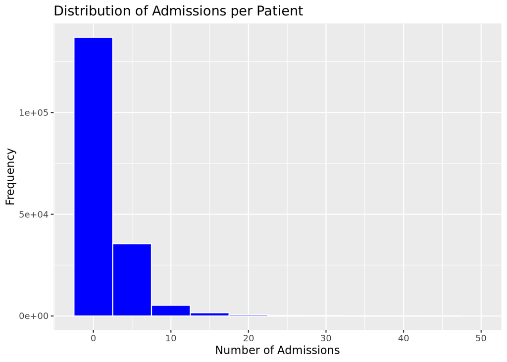

```r
admissions_count_per_patient <- admissions_tble %>%
  group_by(subject_id) %>%
  summarize(admissions_count = n())
ggplot(admissions_count_per_patient, aes(x = admissions_count)) +
  geom_histogram(binwidth = 5, fill = "blue", color = "white") +
  labs(title = "Distribution of Admissions per Patient",
       x = "Number of Admissions",
       y = "Frequency") +
  xlim(NA, 50)
```

Most patients have only one admission, and the number of admissions per patient decreases as the number of admissions. And there are rows removed for N/A data.

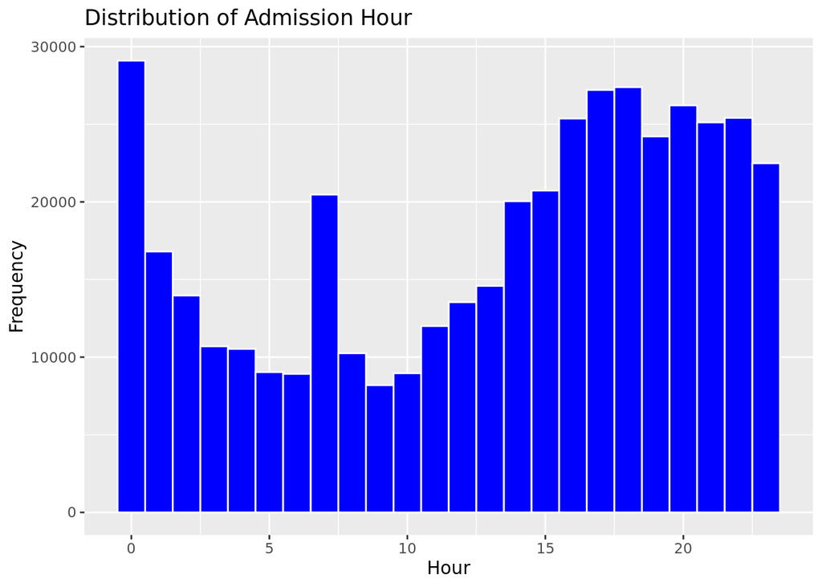

```r
admissions_tble %>%
  mutate(admittime = as.POSIXct(admittime)) %>%
  ggplot(aes(x = hour(admittime))) +
  geom_histogram(binwidth = 1, fill = "blue", color = "white") +
  labs(title = "Distribution of Admission Hour",
       x = "Hour",
       y = "Frequency")
```

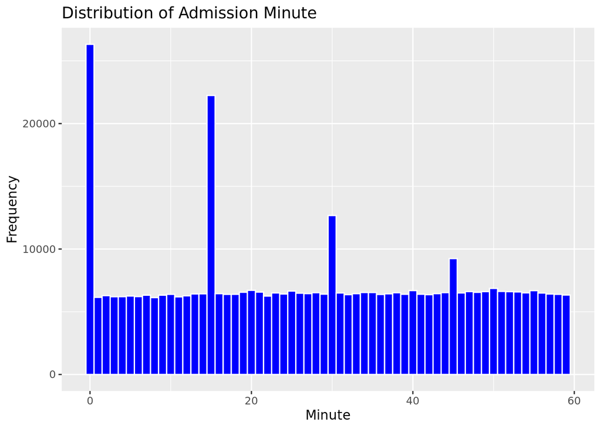

```r
admissions_tble %>%
  mutate(admittime = as.POSIXct(admittime)) %>%
  ggplot(aes(x = minute(admittime))) +
  geom_histogram(binwidth = 1, fill = "blue", color = "white") +
  labs(title = "Distribution of Admission Minute",
       x = "Minute",
       y = "Frequency")
```

There are four peaks in the distribution of admission minutes, which is unusual.

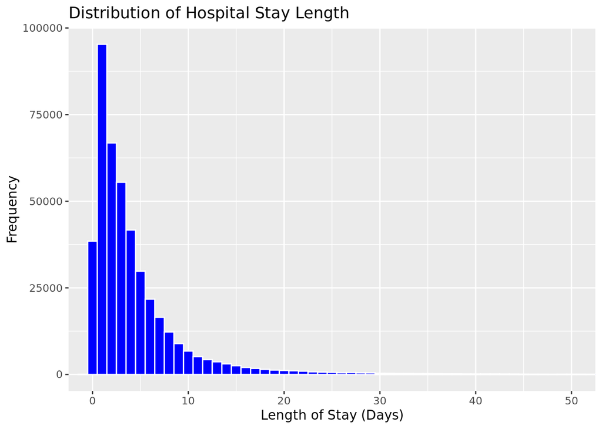

```r
admissions_tble <- admissions_tble %>%
  mutate(hospital_stay_length = as.numeric(
    difftime(dischtime, admittime, units = "days")))

ggplot(admissions_tble, aes(x = hospital_stay_length)) +
  geom_histogram(binwidth = 1, fill = "blue", color = "white") +
  labs(title = "Distribution of Hospital Stay Length",
       x = "Length of Stay (Days)",
       y = "Frequency") +
  coord_cartesian(xlim = c(0, 50))
```

The length of hospital stay is right-skewed, and most patients stay in the hospital for less than 10 days. There are a few patients who stay in the hospital for more than 20 days, generaly is usual.

## Q4. `patients` data

Patient information is available in `patients.csv.gz`. See https://mimic.mit.edu/docs/iv/modules/hosp/patients/ for details of each field in this file. The first 10 lines are

```bash
zcat < ~/mimic/hosp/patients.csv.gz | head
```

```
subject_id,gender,anchor_age,anchor_year,anchor_year_group,dod
10000032,F,52,2180,2014 - 2016,2180-09-09
10000048,F,23,2126,2008 - 2010,
10000068,F,19,2160,2008 - 2010,
10000084,M,72,2160,2017 - 2019,2161-02-13
10000102,F,27,2136,2008 - 2010,
10000108,M,25,2163,2014 - 2016,
10000115,M,24,2154,2017 - 2019,
10000117,F,48,2174,2008 - 2010,
10000178,F,59,2157,2017 - 2019,
```

### Q4.1 Ingestion

Import `patients.csv.gz` (https://mimic.mit.edu/docs/iv/modules/hosp/patients/) as a tibble `patients_tble`.

*Answer*

```r
patients_tble <- read_csv("~/mimic/hosp/patients.csv.gz",
                          show_col_types = FALSE)
```

### Q4.2 Summary and visualization

Summarize variables `gender` and `anchor_age` by graphics, and explain any patterns you see.

*Answer*

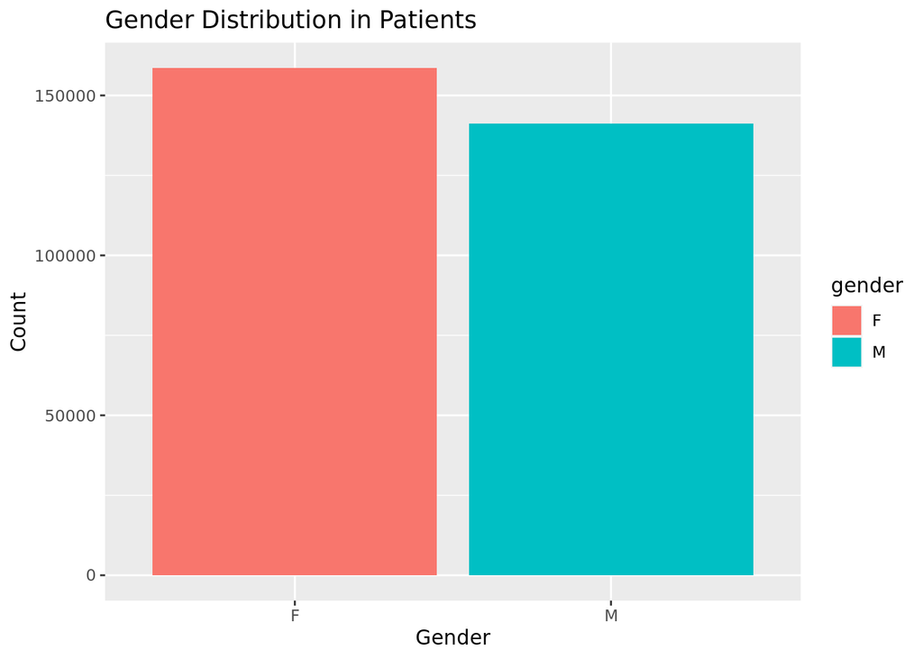

```r
gender_distribution <- patients_tble %>%
  count(gender)

ggplot(gender_distribution, aes(x = gender, y = n, fill = gender)) +
  geom_bar(stat = "identity") +
  labs(title = "Gender Distribution in Patients",
       x = "Gender",
       y = "Count")
```

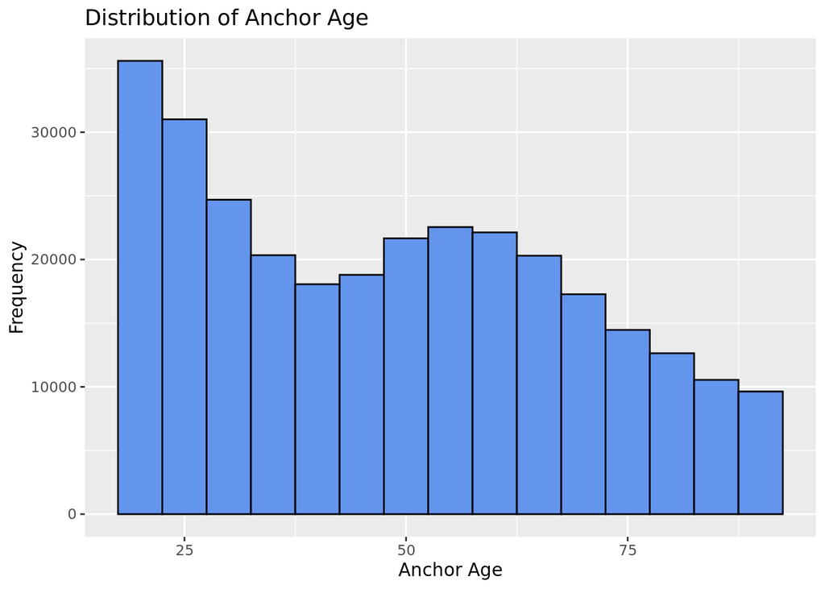

```r
ggplot(patients_tble, aes(x = anchor_age)) +
  geom_histogram(binwidth = 5, fill = "cornflowerblue", color = "black") +
  labs(title = "Distribution of Anchor Age",
       x = "Anchor Age",
       y = "Frequency")
```

From the graph, for gender, it is generally balanced. For anchor age, more patients are between 0 and 25 years old, and the number of patients decreases as the age increases. There is a small peak around 50 years old.

## Q5. Lab results

`labevents.csv.gz` (https://mimic.mit.edu/docs/iv/modules/hosp/labevents/) contains all laboratory measurements for patients. The first 10 lines are

```bash
zcat < ~/mimic/hosp/labevents.csv.gz | head
```

```
labevent_id,subject_id,hadm_id,specimen_id,itemid,order_provider_id,charttime,storetime,value,valuenum,valueuom,ref_range_lower,ref_range_upper,flag,priority,comments
1,10000032,,45421181,51237,P28Z0X,2180-03-23 11:51:00,2180-03-23 15:15:00,1.4,1.4,,0.9,1.1,abnormal,ROUTINE,
2,10000032,,45421181,51274,P28Z0X,2180-03-23 11:51:00,2180-03-23 15:15:00,___,15.1,sec,9.4,12.5,abnormal,ROUTINE,VERIFIED.
3,10000032,,52958335,50853,P28Z0X,2180-03-23 11:51:00,2180-03-25 11:06:00,___,15,ng/mL,30,60,abnormal,ROUTINE,NEW ASSAY IN USE ___: DETECTS D2 AND D3 25-OH ACCURATELY.
4,10000032,,52958335,50861,P28Z0X,2180-03-23 11:51:00,2180-03-23 16:40:00,102,102,IU/L,0,40,abnormal,ROUTINE,
5,10000032,,52958335,50862,P28Z0X,2180-03-23 11:51:00,2180-03-23 16:40:00,3.3,3.3,g/dL,3.5,5.2,abnormal,ROUTINE,
6,10000032,,52958335,50863,P28Z0X,2180-03-23 11:51:00,2180-03-23 16:40:00,109,109,IU/L,35,105,abnormal,ROUTINE,
7,10000032,,52958335,50864,P28Z0X,2180-03-23 11:51:00,2180-03-23 16:40:00,___,8,ng/mL,0,8.7,,ROUTINE,MEASURED BY ___.
8,10000032,,52958335,50868,P28Z0X,2180-03-23 11:51:00,2180-03-23 16:40:00,12,12,mEq/L,8,20,,ROUTINE,
9,10000032,,52958335,50878,P28Z0X,2180-03-23 11:51:00,2180-03-23 16:40:00,143,143,IU/L,0,40,abnormal,ROUTINE,
```

`d_labitems.csv.gz` (https://mimic.mit.edu/docs/iv/modules/hosp/d_labitems/) is the dictionary of lab measurements.

```bash
zcat < ~/mimic/hosp/d_labitems.csv.gz | head
```

```
itemid,label,fluid,category
50801,Alveolar-arterial Gradient,Blood,Blood Gas
50802,Base Excess,Blood,Blood Gas
50803,"Calculated Bicarbonate, Whole Blood",Blood,Blood Gas
50804,Calculated Total CO2,Blood,Blood Gas
50805,Carboxyhemoglobin,Blood,Blood Gas
50806,"Chloride, Whole Blood",Blood,Blood Gas
50808,Free Calcium,Blood,Blood Gas
50809,Glucose,Blood,Blood Gas
50810,"Hematocrit, Calculated",Blood,Blood Gas
```

We are interested in the lab measurements of creatinine (50912), potassium (50971), sodium (50983), chloride (50902), bicarbonate (50882), hematocrit (51221), white blood cell count (51301), and glucose (50931). Retrieve a subset of `labevents.csv.gz` that only containing these items for the patients in `icustays_tble`. Further restrict to the last available measurement (by `storetime`) before the ICU stay. The final `labevents_tble` should have one row per ICU stay and columns for each lab measurement.

*Answer* Read the dictionary

```r
dlabitems_tble <- read_csv("~/mimic/hosp/d_labitems.csv.gz",
                           show_col_types = FALSE) |>
  filter(itemid %in% c(
    50912, 50971, 50983, 50902, 50882, 51221, 51301, 50931
  ))

icustays_tble <- read_csv("~/mimic/icu/icustays.csv.gz",
                          show_col_types = FALSE)

# filter labevents_tble_orig
labevents_tble_orig <- open_dataset("labevents_pq", format = "parquet") %>%
  select(subject_id, itemid, storetime, valuenum) %>%
  filter(itemid %in% dlabitems_tble$itemid) %>%
  filter(subject_id %in% icustays_tble$subject_id) %>%
  collect()
```

```r
labevents_tble <- labevents_tble_orig %>%
  # left join with icustays_tble to get intime
  left_join(
    select(icustays_tble, subject_id, stay_id, intime),
    by = "subject_id"
  ) %>%
  # filter to get the last available measurement before the ICU stay
  filter(storetime < intime) %>%
  group_by(subject_id, stay_id, itemid) %>%
  # arrange by storetime and select the last measurement
  arrange(storetime, .by_group = TRUE) %>%
  slice_tail(n = 1) %>%
  select(-storetime, -intime) %>%
  # pivot_wider to get one row per ICU stay
  pivot_wider(names_from = itemid, values_from = valuenum)
```

rename the columns

```r
#rename the columns
item_to_label <- dlabitems_tble %>%
  deframe()
labevents_tble <- labevents_tble %>%
  rename_with(.fn = ~ifelse(.x %in% names(item_to_label),
                            item_to_label[.x], .x), .cols = everything())

print(labevents_tble, width = Inf)
```

```
# A tibble: 68,467 × 10
# Groups:   subject_id, stay_id [68,467]
   subject_id  stay_id Bicarbonate Chloride Creatinine Glucose Potassium Sodium
        <dbl>    <dbl>       <dbl>    <dbl>      <dbl>   <dbl>     <dbl>  <dbl>
 1   10000032 39553978          25       95        0.7     102       6.7    126
 2   10000980 39765666          21      109        2.3      89       3.9    144
 3   10001217 34592300          30      104        0.5      87       4.1    142
 4   10001217 37067082          22      108        0.6     112       4.2    142
 5   10001725 31205490          NA       98       NA        NA       4.1    139
 6   10001884 37510196          30       88        1.1     141       4.5    130
 7   10002013 39060235          24      102        0.9     288       3.5    137
 8   10002155 31090461          23       98        2.8     117       4.9    135
 9   10002155 32358465          26       85        1.4     133       5.7    120
10   10002155 33685454          24      105        1.1     138       4.6    139
   Hematocrit `White Blood Cells`
        <dbl>               <dbl>
 1       41.1                 6.9
 2       27.3                 5.3
 3       37.4                 5.4
 4       38.1                15.7
 5       NA                  NA
 6       39.7                12.2
 7       34.9                 7.2
 8       25.5                17.9
 9       22.4                 9.8
10       39.7                 7.9
# ℹ 68,457 more rows
```

## Q6. Vitals from charted events

`chartevents.csv.gz` (https://mimic.mit.edu/docs/iv/modules/icu/chartevents/) contains all the charted data available for a patient. During their ICU stay, the primary repository of a patient’s information is their electronic chart. The `itemid` variable indicates a single measurement type in the database. The `value` variable is the value measured for `itemid`. The first 10 lines of `chartevents.csv.gz` are

```bash
zcat < ~/mimic/icu/chartevents.csv.gz | head
```

[output not shown]

`d_items.csv.gz` (https://mimic.mit.edu/docs/iv/modules/icu/d_items/) is the dictionary for the `itemid` in `chartevents.csv.gz`.

```bash
zcat < ~/mimic/icu/d_items.csv.gz | head
```

[output not shown]

We are interested in the vitals for ICU patients: heart rate (220045), systolic non-invasive blood pressure (220179), diastolic non-invasive blood pressure (220180), body temperature in Fahrenheit (223761), and respiratory rate (220210). Retrieve a subset of `chartevents.csv.gz` only containing these items for the patients in `icustays_tble`. Further restrict to the first vital measurement within the ICU stay. The final `chartevents_tble` should have one row per ICU stay and columns for each vital measurement.

[figure not shown]

Hint: Use the Parquet format you generated in Homework 2. For reproducibility, make `chartevents_pq` folder available at the current working directory, for example, by a symbolic link.

```r
# Read the item dictionary to map itemid to labels
d_items_tble <- read_csv("~/mimic/icu/d_items.csv.gz",
                           show_col_types = FALSE) |>
# Specify the item IDs for the vitals of interest
  filter(itemid %in% c(
    220045, 220179, 220180, 223761, 220210
  ))
```

```r
icustays_tble <- read_csv("~/mimic/icu/icustays.csv.gz",
                          show_col_types = FALSE)
# read Parquet data
chartevents_tble_orig <- open_dataset("chartevents_pq", format = "parquet") %>%
  select(subject_id, itemid, charttime, valuenum) %>%
  filter(itemid %in% d_items_tble$itemid) %>%
  filter(subject_id %in% icustays_tble$subject_id) %>%
  collect()

chartevents_tble <- chartevents_tble_orig %>%
  left_join(
    select(icustays_tble, subject_id, stay_id, intime, outtime),
    by = "subject_id"
  ) %>%
  filter(charttime >= intime & charttime <= outtime) %>%
  group_by(subject_id, stay_id, itemid) %>%
  arrange(charttime, .by_group = TRUE) %>%
  slice_head(n = 1) %>%
  ungroup() %>%
  select(-charttime, -intime, outtime) %>%
  pivot_wider(names_from = itemid, values_from = valuenum)
```

```r
#rename the columns
item_to_label <- d_items_tble %>%
  deframe()
chartevents_tble <- chartevents_tble %>%
  rename_with(.fn = ~ifelse(.x %in% names(item_to_label),
                            item_to_label[.x], .x), .cols = everything())

print(chartevents_tble, width = Inf)
```

```
# A tibble: 73,164 × 8
   subject_id  stay_id outtime             `Heart Rate`
        <dbl>    <dbl> <dttm>                     <dbl>
 1   10000032 39553978 2180-07-23 23:50:47           91
 2   10000980 39765666 2189-06-27 20:38:27           77
 3   10001217 34592300 2157-12-20 14:27:41           96
 4   10001217 37067082 2157-11-21 22:08:00           86
 5   10001725 31205490 2110-04-12 23:59:56           55
 6   10001884 37510196 2131-01-20 08:27:30           38
 7   10002013 39060235 2160-05-19 17:33:33           80
 8   10002155 31090461 2130-09-27 22:13:41           94
 9   10002155 32358465 2131-03-10 18:09:21           98
10   10002155 33685454 2129-08-10 17:02:38           68
   `Non Invasive Blood Pressure systolic`
                                    <dbl>
```

[output cut: 35 more lines]

## Q7. Putting things together

Let us create a tibble `mimic_icu_cohort` for all ICU stays, where rows are all ICU stays of adults (age at `intime` >= 18) and columns contain at least following variables

- all variables in `icustays_tble`
- all variables in `admissions_tble`
- all variables in `patients_tble`
- the last lab measurements before the ICU stay in `labevents_tble`
- the first vital measurements during the ICU stay in `chartevents_tble`

The final `mimic_icu_cohort` should have one row per ICU stay and columns for each variable.

*Answer*

```r
admissions_tble <- read_csv("~/mimic/hosp/admissions.csv.gz",
                            show_col_types = FALSE)
icustays_tble <- read_csv("~/mimic/icu/icustays.csv.gz",
                          show_col_types = FALSE)
patients_tble <- read_csv("~/mimic/hosp/patients.csv.gz",
                          show_col_types = FALSE)
# get the age at intime
icu_adults <- icustays_tble %>%
  left_join(patients_tble, by = "subject_id") %>%
  mutate(age_at_intime = anchor_age + year(intime) - anchor_year) %>%
  # filter to keep only adults
  filter(age_at_intime >= 18)
mimic_icu_cohort <- icu_adults %>%
  left_join(admissions_tble, by = "hadm_id")
mimic_icu_cohort <- mimic_icu_cohort %>%
  left_join(labevents_tble, by = c("stay_id"))
mimic_icu_cohort <- mimic_icu_cohort %>%
  left_join(chartevents_tble, by = c("stay_id"))|>
  print(width = Inf)
```

```
# A tibble: 73,181 × 45
   subject_id.x  hadm_id  stay_id
          <dbl>    <dbl>    <dbl>
 1     10000032 29079034 39553978
 2     10000980 26913865 39765666
 3     10001217 24597018 37067082
 4     10001217 27703517 34592300
 5     10001725 25563031 31205490
 6     10001884 26184834 37510196
 7     10002013 23581541 39060235
 8     10002155 20345487 32358465
 9     10002155 23822395 33685454
10     10002155 28994087 31090461
   first_careunit
   <chr>
```

[output cut: 143 more lines]

## Q8. Exploratory data analysis (EDA)

Summarize the following information about the ICU stay cohort `mimic_icu_cohort` using appropriate numerics or graphs:

- Length of ICU stay `los` vs demographic variables (race, insurance, marital_status, gender, age at intime)

```r
# Check the structure of mimic_icu_cohort to ensure the presence of all variables
str(mimic_icu_cohort)
```

[output not shown]

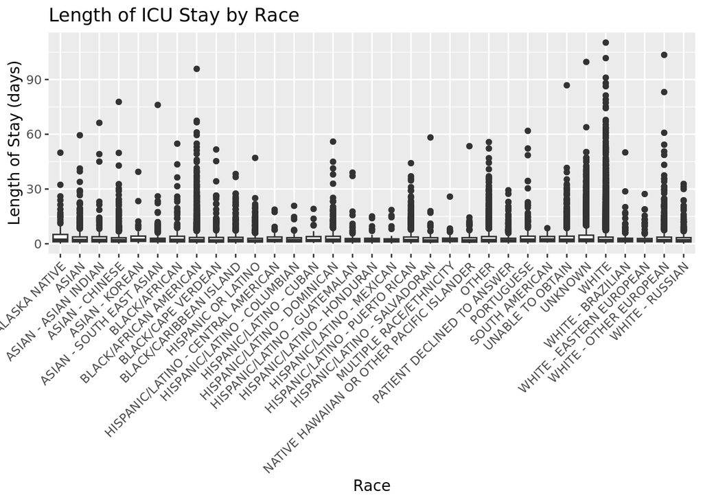

```r
# Summarize and plot Length of ICU stay by race
ggplot(mimic_icu_cohort, aes(x = race, y = los)) +
  geom_boxplot() +
  labs(title = "Length of ICU Stay by Race",
       x = "Race", y = "Length of Stay (days)") +
  theme(axis.text.x = element_text(angle = 45, hjust = 1))
```

The boxplot visualizes the lengths of ICU stays categorized by race. It seems that the median length of stay, indicated by the line within each box, is fairly consistent across different racial groups; however, it’s important to note that the scale of the y-axis might compress the boxes, making differences in medians appear less pronounced.

The numerous points above the upper whiskers of the boxplots represent outliers, which are individual ICU stay lengths that fall well outside the typical range for each category. These outliers suggest that while the median stay is similar across groups, there are cases within every racial category with substantially longer ICU stays than the median. This indicates variability and the presence of extreme values in the dataset. The consistency of the medians does not imply that the experiences of ICU stays are uniform across races, as the outliers and the range of the interquartile distances (the height of the boxes) reveal differences in the distribution of stays.

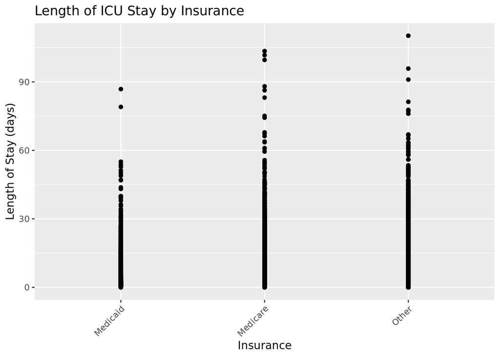

```r
# Summarize and plot Length of ICU stay by insurance
ggplot(mimic_icu_cohort, aes(x = insurance, y = los)) +
  geom_point() +
  labs(title = "Length of ICU Stay by Insurance", x = "Insurance",
       y = "Length of Stay (days)") +
  theme(axis.text.x = element_text(angle = 45, hjust = 1))
```

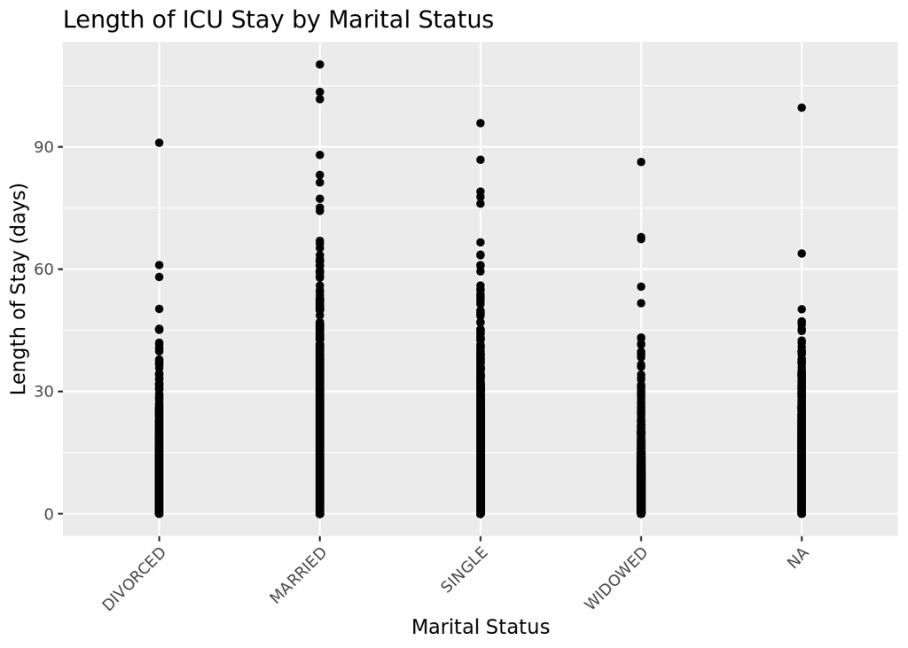

```r
# Summarize and plot Length of ICU stay by marital_status
ggplot(mimic_icu_cohort, aes(x = marital_status, y = los)) +
  geom_point() +
  labs(title = "Length of ICU Stay by Marital Status",
       x = "Marital Status", y = "Length of Stay (days)") +
  theme(axis.text.x = element_text(angle = 45, hjust = 1))
```

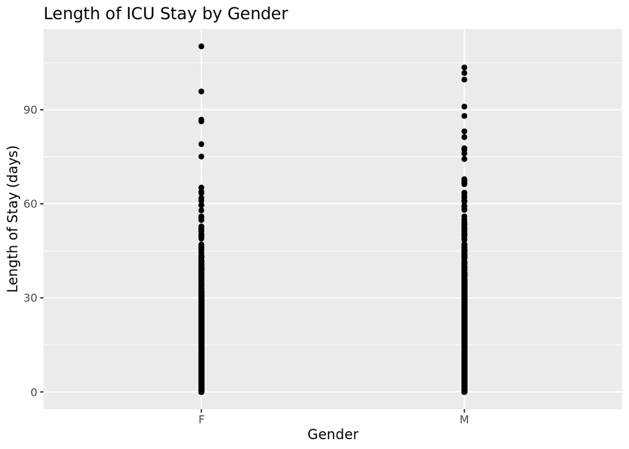

```r
# Summarize and plot Length of ICU stay by gender
ggplot(mimic_icu_cohort, aes(x = gender, y = los)) +
  geom_point() +
  labs(title = "Length of ICU Stay by Gender", x = "Gender",
       y = "Length of Stay (days)")
```

The scatter plot visualizes the lengths of ICU stays categorized by gender. The plot shows that the distribution of ICU stay lengths is similar for both gender. But with a little longer stay of women due to the outliers.

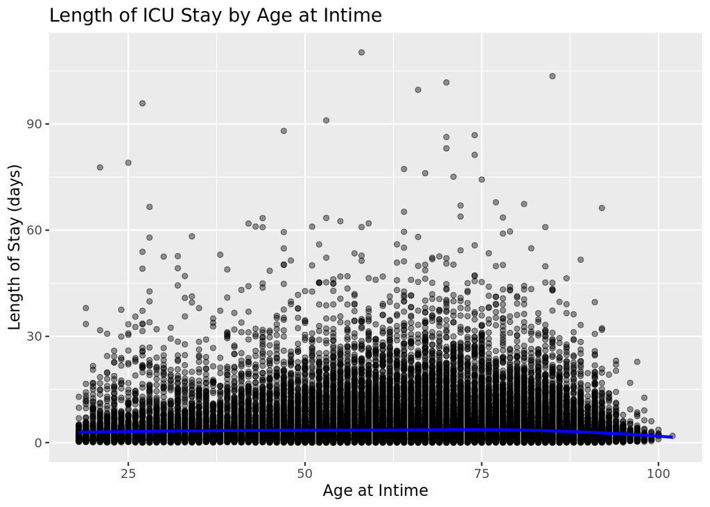

```r
# Summarize and plot Length of ICU stay by age at intime
# For age, since it's a continuous variable, we use a scatter plot with a smoothing line
ggplot(mimic_icu_cohort, aes(x = age_at_intime, y = los)) +
  geom_point(alpha = 0.4) +
  geom_smooth(method = "loess", se = FALSE, color = "blue") +
  labs(title = "Length of ICU Stay by Age at Intime", x = "Age at Intime",
       y = "Length of Stay (days)")
```

The scatter plot visualizes the lengths of ICU stays categorized by age at intime. The plot shows that the distribution of ICU stay lengths is similar across age groups, with no clear differences in the median length of stay. However, the plot also shows that there are more patients in the age range around 75 years, and fewer patients in the age range of 85-100 years.

- Length of ICU stay `los` vs the last available lab measurements before ICU stay

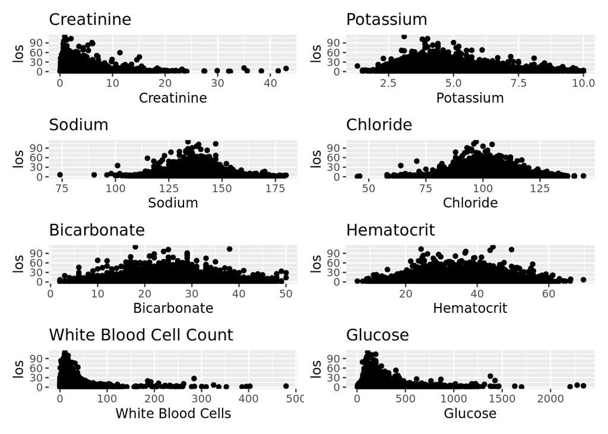

```r
library(ggplot2)
library(patchwork)
#individual plots for labevents
p1 <- ggplot(mimic_icu_cohort, aes(x = Creatinine, y = los))+
  geom_point() + labs(title = "Creatinine")
p2 <- ggplot(mimic_icu_cohort, aes(x = Potassium, y = los)) +
  geom_point() + labs(title = "Potassium")
p3 <- ggplot(mimic_icu_cohort, aes(x = Sodium, y = los)) +
  geom_point() + labs(title = "Sodium")
p4 <- ggplot(mimic_icu_cohort, aes(x = Chloride, y = los)) +
  geom_point() + labs(title = "Chloride")
p5 <- ggplot(mimic_icu_cohort, aes(x = Bicarbonate, y = los)) +
  geom_point() + labs(title = "Bicarbonate")
p6 <- ggplot(mimic_icu_cohort, aes(x = Hematocrit, y = los)) +
  geom_point() + labs(title = "Hematocrit")
p7 <- ggplot(mimic_icu_cohort, aes(x = `White Blood Cells`, y = los)) +
  geom_point() + labs(title = "White Blood Cell Count")
p8 <- ggplot(mimic_icu_cohort, aes(x = Glucose, y = los)) +
  geom_point() + labs(title = "Glucose")

p_combined <- p1 + p2 + p3 + p4 + p5 + p6 + p7 + p8

p_combined <- p_combined + plot_layout(ncol = 2)

p_combined
```

- Length of ICU stay los vs the first vital measurements within the ICU stay

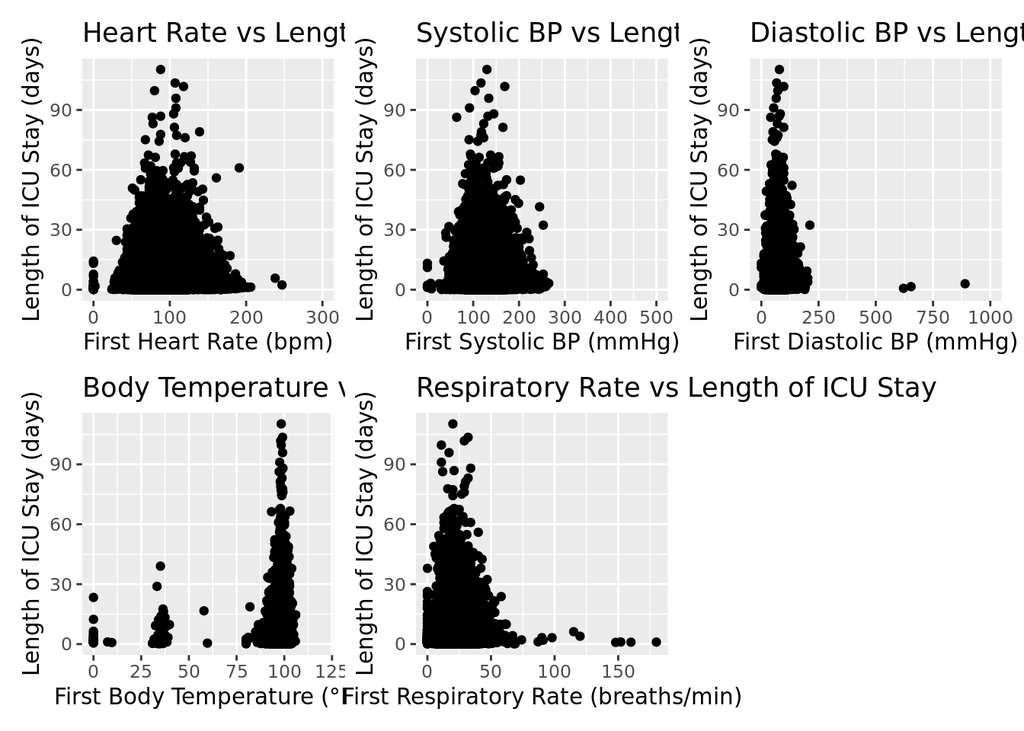

```r
p_heart_rate <- ggplot(mimic_icu_cohort, aes(x = `Heart Rate`, y = los)) +
  geom_point() +
  coord_cartesian(xlim = c(0, 300)) +
  labs(title = "Heart Rate vs Length of ICU Stay",
       x = "First Heart Rate (bpm)", y = "Length of ICU Stay (days)")

# Scatter plot for systolic blood pressure with x-axis limits
p_systolic_bp <- ggplot(mimic_icu_cohort, aes(x = `Non Invasive Blood Pressure systolic`, y = los)) +
  geom_point() +
  coord_cartesian(xlim = c(0, 500)) +
  labs(title = "Systolic BP vs Length of ICU Stay",
       x = "First Systolic BP (mmHg)", y = "Length of ICU Stay (days)")

# Scatter plot for diastolic blood pressure with x-axis limits
p_diastolic_bp <- ggplot(mimic_icu_cohort,
                         aes(x = `Non Invasive Blood Pressure diastolic`,
                             y = los)) +
  geom_point() +
  coord_cartesian(xlim = c(0, 1000)) +
  labs(title = "Diastolic BP vs Length of ICU Stay",
       x = "First Diastolic BP (mmHg)", y = "Length of ICU Stay (days)")

# Scatter plot for body temperature with x-axis limits
p_temperature_f <- ggplot(mimic_icu_cohort,
                          aes(x = `Temperature Fahrenheit`, y = los)) +
  geom_point() +
  coord_cartesian(xlim = c(0, 120)) +
  labs(title = "Body Temperature vs Length of ICU Stay",
       x = "First Body Temperature (°F)", y = "Length of ICU Stay (days)")

# Scatter plot for respiratory rate (no change in x-axis limits)
p_respiratory_rate <- ggplot(mimic_icu_cohort,
                             aes(x = `Respiratory Rate`, y = los)) +
  geom_point() +
  labs(title = "Respiratory Rate vs Length of ICU Stay",
       x = "First Respiratory Rate (breaths/min)",
       y = "Length of ICU Stay (days)")

# Combine the plots
p_combined <- p_heart_rate | p_systolic_bp | p_diastolic_bp |
  p_temperature_f | p_respiratory_rate
p_combined + plot_layout(ncol = 3, nrow = 2)
```

The first graph shows the relationship between the first heart rate measurement and the length of ICU stay. First heart beat rate around 100 has the longest stay in ICU. The second graph shows the relationship between the first systolic blood pressure measurement and the length of ICU stay. BP around 100 tent to have the logest stay. The third graph shows the relationship between the first diastolic blood pressure measurement and the length of ICU stay and have similar pattern. The fourth graph shows the relationship between the first body temperature measurement and the length of ICU stay. Body temperature around 100 tend to have longest icu stay. The fifth graph shows the relationship between the first respiratory rate measurement and the length of ICU stay. Breath around 25 breaths/min tend to have the longest stay in ICU.

- Length of ICU stay `los` vs first ICU

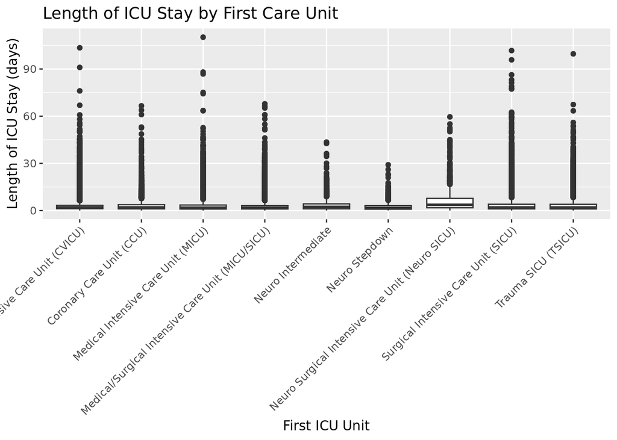

```r
library(ggplot2)

# Create a boxplot of ICU stay length by the first ICU unit
p_first_care_unit <- ggplot(mimic_icu_cohort, aes(x = first_careunit,
                                                  y = los)) +
  geom_boxplot() +
  labs(title = "Length of ICU Stay by First Care Unit",
       x = "First ICU Unit",
       y = "Length of ICU Stay (days)") +
  theme(axis.text.x = element_text(angle = 45, hjust = 1))  # Rotate x labels for better readability

# Print the plot
print(p_first_care_unit)
```

I created a boxplot to visualize the distribution of ICU stay lengths by the first ICU unit. The plot shows that the median length of stay is fairly consistent across different ICU units, with the exception of the Neuro SICU unit, which has a slightly longer upper quantile stay. The plot also shows that there are less patients stayed at Neuro Intermediate Care Unit and Neuro Stepdown.